# test1

## Prerequisites

### 1. Required imports

```python
from utility import download_and_unzip

import warnings
import pandas as pd
import numpy as np
import statsmodels.api as sm
import matplotlib.pyplot as plt

from statsmodels.tsa.stattools import adfuller, kpss
from statsmodels.tsa.seasonal import seasonal_decompose
from statsmodels.graphics.tsaplots import plot_acf, plot_pacf

from statsmodels.tsa.arima.model import ARIMA
from statsmodels.tsa.statespace.sarimax import SARIMAX

warnings.filterwarnings("ignore")
```

### 2. Common functions

#### 1. Check whether the time series is stationary using ADF Test.

```python
# Dickey-Fuller test
# warnings.filterwarnings("ignore")
def dickey_fuller_test(series):
    print("\nADF Test H0: The time series is non-stationary")
    print("\nResults of Dickey-Fuller Test:")
    dftest = adfuller(series, autolag="AIC")
    dfoutput = pd.Series(
        dftest[0:4],
        index=[
            "Test Statistic",
            "p-value",
            "#Lags Used",
            "Number of Observations Used",
        ],
    )
    for key, value in dftest[4].items():
        dfoutput["Critical Value (%s)" % key] = value
    print(dfoutput)
    if dftest[1] <= 0.05:
        return "***** ADF Test: Reject the H0: The time series is stationary"
    else:
        return (
            "***** ADF Test: Fail to reject the H0: The time series is non-stationary"
        )
```

#### 2. Check for stationarity using KPSS test

```python
# Applying KPSS test for Production series
def kpss_test(series):
    print("\nKPSS test H0: The series is stationary")
    # result = kpss(df["Sales"])
    result = kpss(series)
    # print(result)
    print("\nKPSS Test Statistic: %.2f" % result[0])
    print("p-value: %.2f" % result[1])
    print("1%% Critical Value: %.2f" % result[3]["1%"])
    print("5%% Critical Value: %.2f" % result[3]["5%"])
    print("10%% Critical Value: %.2f" % result[3]["10%"])
    if result[1] <= 0.05:
        return "***** KPSS Test: Rejected the H0: The series is non-stationary"

    else:
        return "***** KPSS Test: Failed to reject the H0:  The series is stationary"
```

#### 3. Perform both stationarity checks in one go

```python
def perform_stationarity_tests(series):
    print("\n   ----- Performing Dickey-Fuller Test -----")
    dickey_fuller_result = dickey_fuller_test(series)

    print("\n   ----- Performing KPSS Test -----")
    kpss_result = kpss_test(series)

    print("\n\n   ----- Test Summary -----")
    print(dickey_fuller_result)
    print(kpss_result)
```

#### 4. Plot both PACF and ACF in one go to compare

```python
# Plot both PACF and ACF graphs
def plot_pacf_acf(series, lags=40):
    fig, axes = plt.subplots(1, 2, figsize=(14, 5))

    plot_pacf(series, lags=lags, ax=axes[0])
    axes[0].set_title("Partial Autocorrelation (PACF)")
    axes[0].set_xlabel("Lag")
    axes[0].set_ylabel("PACF")

    plot_acf(series, lags=lags, ax=axes[1])
    axes[1].set_title("Autocorrelation (ACF)")
    axes[1].set_xlabel("Lag")
    axes[1].set_ylabel("ACF")
    plt.tight_layout()
    plt.show()
```

#### 5. Plot a time series

```python
def plot_time_series(series):
    series.plot(figsize=(14, 4), title="Monthly Car Sales")
    series.rolling(window=12).mean().plot(label="12 Mean")
    series.rolling(window=12).std().plot(label="12 STD")
    plt.legend()
    plt.show()
```

## Load, read and prepare data for further EDA and Time series modelling

### 1. download the data only once

```python
# !wget -qq https://raw.githubusercontent.com/jbrownlee/Datasets/master/monthly-car-sales.csv

download_and_unzip(
    filename="monthly-car-sales.csv",
    url="https://raw.githubusercontent.com/jbrownlee/Datasets/master/monthly-car-sales.csv",
)

print("Data downloaded successfully")
```

```
Data downloaded successfully
```

### 2. Load the data

```python
df_ = pd.read_csv("monthly-car-sales.csv")
df_
```

|  | Month | Sales |
| --- | --- | --- |
| 0 | 1960-01 | 6550 |
| 1 | 1960-02 | 8728 |
| 2 | 1960-03 | 12026 |
| 3 | 1960-04 | 14395 |
| 4 | 1960-05 | 14587 |
| ... | ... | ... |
| 103 | 1968-08 | 16722 |
| 104 | 1968-09 | 14385 |
| 105 | 1968-10 | 21342 |
| 106 | 1968-11 | 17180 |
| 107 | 1968-12 | 14577 |

108 rows × 2 columns

```python
df_["year"] = df_["Month"].apply(lambda x: int(x.split("-")[0]))
df_["month"] = df_["Month"].apply(lambda x: int(x.split("-")[1]))
df_["date"] = pd.to_datetime(df_[["year", "month"]].assign(day=1))
df_ = df_.set_index("date")
df = df_.drop(columns=["Month", "year", "month"])

print(df_.head())
print(df.head())
```

```
              Month  Sales  year  month
date
1960-01-01  1960-01   6550  1960      1
1960-02-01  1960-02   8728  1960      2
1960-03-01  1960-03  12026  1960      3
1960-04-01  1960-04  14395  1960      4
1960-05-01  1960-05  14587  1960      5
            Sales
date
1960-01-01   6550
1960-02-01   8728
1960-03-01  12026
1960-04-01  14395
1960-05-01  14587
```

#### 3. Check some basic statistics of the data

```python
# find the basic information of the dataset
df.info()
df.describe()
```

```
<class 'pandas.core.frame.DataFrame'>
DatetimeIndex: 108 entries, 1960-01-01 to 1968-12-01
Data columns (total 1 columns):
 #   Column  Non-Null Count  Dtype
---  ------  --------------  -----
 0   Sales   108 non-null    int64
dtypes: int64(1)
memory usage: 1.7 KB
```

|  | Sales |
| --- | --- |
| count | 108.000000 |
| mean | 14595.111111 |
| std | 4525.213913 |
| min | 5568.000000 |
| 25% | 11391.250000 |
| 50% | 14076.000000 |
| 75% | 17595.750000 |
| max | 26099.000000 |

```python
# find the basic statistics of the dataset
df.describe()
```

|  | Sales |
| --- | --- |
| count | 108.000000 |
| mean | 14595.111111 |
| std | 4525.213913 |
| min | 5568.000000 |
| 25% | 11391.250000 |
| 50% | 14076.000000 |
| 75% | 17595.750000 |
| max | 26099.000000 |

```python
# Are there any missing values in the dataset?
notNA = df.notna().all(axis=1).sum()
print(f"there are {notNA - len(df)} missing values in the dataset")
```

```
there are 0 missing values in the dataset
```

## Question a. Plot the time series and comment on the trend and seasonality.

### 1. Plot the original time series

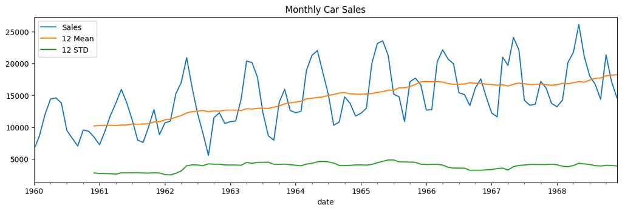

```python
plot_time_series(df["Sales"])
```

### Comment-1

1. We clearly see that original data has a mean moving upwards. Trend is upwards.
2. Original data is likely to be non-stationary as it has it has trend in the data.

### 2. Plot the yearly sales data to show seasonality

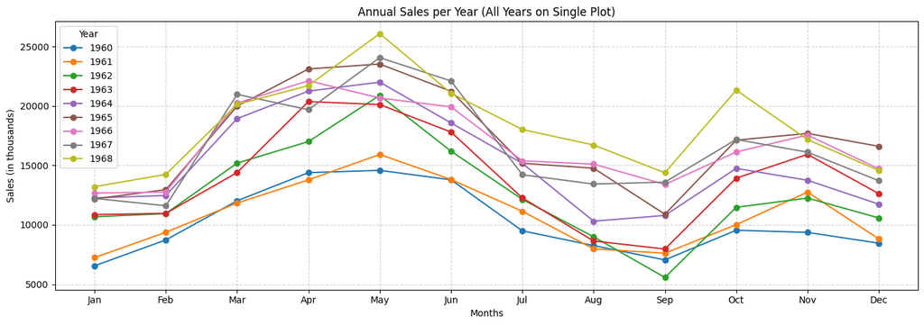

```python
years = df_["year"].unique()
plt.figure(figsize=(14, 5))

for year in years:
    yearly_data = df_[df_["year"] == year]
    plt.plot(
        yearly_data["month"],
        yearly_data["Sales"],
        marker="o",
        label=str(year),
    )

plt.title("Annual Sales per Year (All Years on Single Plot)")
plt.xlabel("Months")
plt.ylabel("Sales (in thousands)")
plt.xticks(
    [1, 2, 3, 4, 5, 6, 7, 8, 9, 10, 11, 12],
    [
        "Jan",
        "Feb",
        "Mar",
        "Apr",
        "May",
        "Jun",
        "Jul",
        "Aug",
        "Sep",
        "Oct",
        "Nov",
        "Dec",
    ],
)
plt.grid(True, linestyle="--", alpha=0.6)
plt.legend(title="Year")
plt.tight_layout()
plt.show()
```

### Comment-2

1. In the above graph we see the sales pattern repeat Year-on-Year i.e. it has a seasonality of 12 months.
2. Sales typically spikes up during April, May (highest) and June and remains at the lowest sales in Sep and Jan.

## Question b. Determine the stationarity of the time series using a suitable test.

### 1. Perform Stationarity tests

```python
perform_stationarity_tests(df["Sales"])
```

```
   ----- Performing Dickey-Fuller Test -----

ADF Test H0: The time series is non-stationary

Results of Dickey-Fuller Test:
Test Statistic                 -1.223813
p-value                         0.663269
#Lags Used                     12.000000
Number of Observations Used    95.000000
Critical Value (1%)            -3.501137
Critical Value (5%)            -2.892480
Critical Value (10%)           -2.583275
dtype: float64

   ----- Performing KPSS Test -----

KPSS test H0: The series is stationary

KPSS Test Statistic: 1.25
p-value: 0.01
1% Critical Value: 0.74
5% Critical Value: 0.46
10% Critical Value: 0.35


   ----- Test Summary -----
***** ADF Test: Fail to reject the H0: The time series is non-stationary
***** KPSS Test: Rejected the H0: The series is non-stationary
```

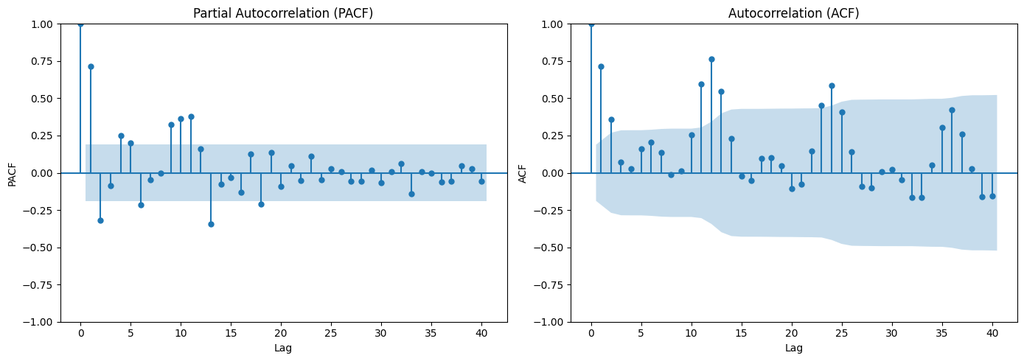

```
We see that the ACF and PACF plots show a slow decay, indicating that the series is likely non-stationary.
This suggests that we may need to difference the series to achieve stationarity before fitting an ARIMA model.
```

```python
# let's check the AR and MA behavior of the non-stationary data before any kind of treatment.
plot_pacf_acf(df["Sales"], lags=40)
print(
    "We see that the ACF and PACF plots show a slow decay, indicating that the series is likely non-stationary. \nThis suggests that we may need to difference the series to achieve stationarity before fitting an ARIMA model."
)
```

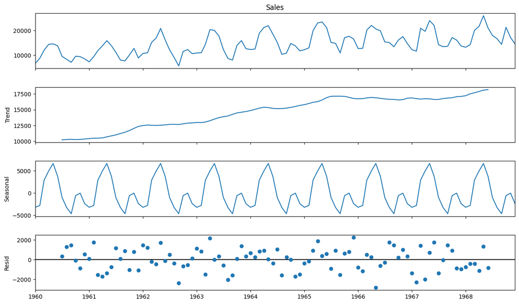

```python
# Let's look at the trend and seasonality of the data
decomposition = seasonal_decompose(df["Sales"], model="additive", period=12)
fig = decomposition.plot()
fig.set_size_inches(14, 8)
plt.show()
```

### Comment-3

1. Looking at the ADF and KPSS test result we can conclude the time series `data is non-stationary`.
2. PACF and ACF too hints in the same direction.

## Question c. Make the series stationary by using log transformation and/or appropriate differencing. Then test if the time series is stationary using a suitable test.

### 1. Removing trend component and then performing stationarity tests

```python
df["Sales"] = np.log(df["Sales"])
df_diff_detrended = df.diff().dropna()  # Differencing to remove trend
```

```python
perform_stationarity_tests(df_diff_detrended["Sales"])
print("\n\nAfter differencing, the series appears to be stationary.")
```

```
   ----- Performing Dickey-Fuller Test -----

ADF Test H0: The time series is non-stationary

Results of Dickey-Fuller Test:
Test Statistic                 -4.193835
p-value                         0.000675
#Lags Used                     12.000000
Number of Observations Used    94.000000
Critical Value (1%)            -3.501912
Critical Value (5%)            -2.892815
Critical Value (10%)           -2.583454
dtype: float64

   ----- Performing KPSS Test -----

KPSS test H0: The series is stationary

KPSS Test Statistic: 0.03
p-value: 0.10
1% Critical Value: 0.74
5% Critical Value: 0.46
10% Critical Value: 0.35


   ----- Test Summary -----
***** ADF Test: Reject the H0: The time series is stationary
***** KPSS Test: Failed to reject the H0:  The series is stationary


After differencing, the series appears to be stationary.
```

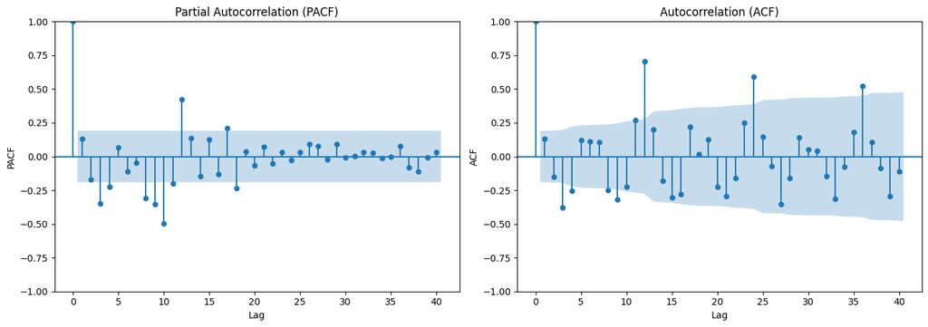

```python
# Let's check the AR and MA behavior of the non-stationary data after differencing as now it's stationary
plot_pacf_acf(df_diff_detrended["Sales"], lags=40)
```

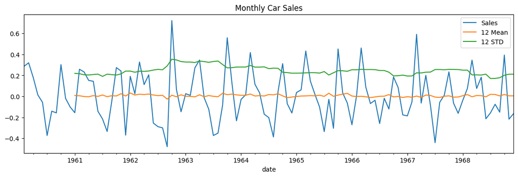

```python
# Let's plot the time series after differencing (detrending)
plot_time_series(df_diff_detrended["Sales"])
```

### 2. Additionally let's remove seasonality component and then performing stationarity tests

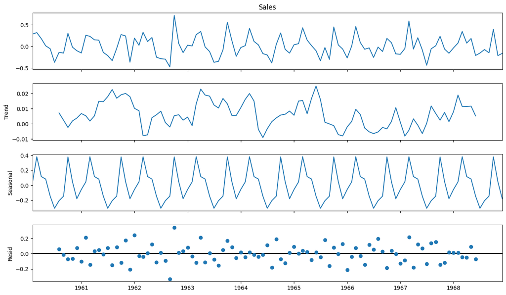

```python
decomposition = seasonal_decompose(
    df_diff_detrended["Sales"], model="additive", period=12
)
fig = decomposition.plot()
fig.set_size_inches(14, 8)
plt.show()
```

```python
df_diff_detrended_deseasoned = (
    df_diff_detrended.copy()
)  # Create a copy for further processing
deseasoned = df_diff_detrended["Sales"] - decomposition.seasonal
df_diff_detrended_deseasoned["Deseasoned_Sales"] = deseasoned
df_diff_detrended_deseasoned.drop(columns=["Sales"], axis=1, inplace=True)
df_diff_detrended_deseasoned.dropna(inplace=True)
df_diff_detrended_deseasoned.rename(columns={"Deseasoned_Sales": "Sales"}, inplace=True)
```

```python
perform_stationarity_tests(df_diff_detrended_deseasoned)
print(
    "\n\nAfter removing seasonality, the series appears to remain stationary after previous detrending."
)
```

```
   ----- Performing Dickey-Fuller Test -----

ADF Test H0: The time series is non-stationary

Results of Dickey-Fuller Test:
Test Statistic                -6.754624e+00
p-value                        2.892736e-09
#Lags Used                     9.000000e+00
Number of Observations Used    9.700000e+01
Critical Value (1%)           -3.499637e+00
Critical Value (5%)           -2.891831e+00
Critical Value (10%)          -2.582928e+00
dtype: float64

   ----- Performing KPSS Test -----

KPSS test H0: The series is stationary

KPSS Test Statistic: 0.22
p-value: 0.10
1% Critical Value: 0.74
5% Critical Value: 0.46
10% Critical Value: 0.35


   ----- Test Summary -----
***** ADF Test: Reject the H0: The time series is stationary
***** KPSS Test: Failed to reject the H0:  The series is stationary


After removing seasonality, the series appears to remain stationary after previous detrending.
```

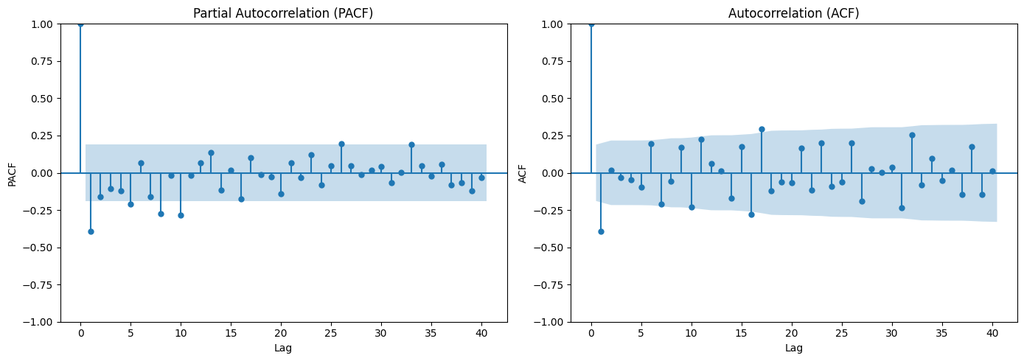

```
 After detrending and deseasonality, the series shows clear AR and MA behavior, indicating that it is now stationary and suitable for ARIMA modeling.
```

```python
plot_pacf_acf(df_diff_detrended_deseasoned, lags=40)
print(
    "\n\n After detrending and deseasonality, the series shows clear AR and MA behavior, indicating that it is now stationary and suitable for ARIMA modeling."
)
```

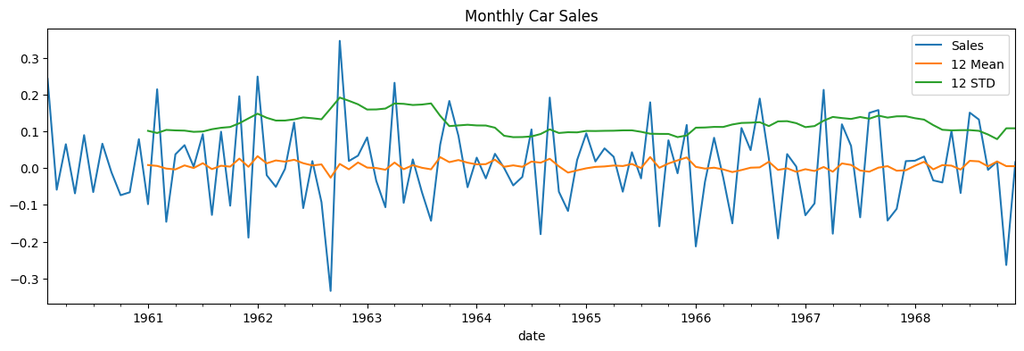

```python
# let's plot the time series after detrending and deseasonality
plot_time_series(df_diff_detrended_deseasoned["Sales"])
```

### Comment-4

1. After detrending the `time series became stationary`.

## Question d. Plot the ACF and PACF of the time series. Do you observe seasonality? If yes, at what lag?

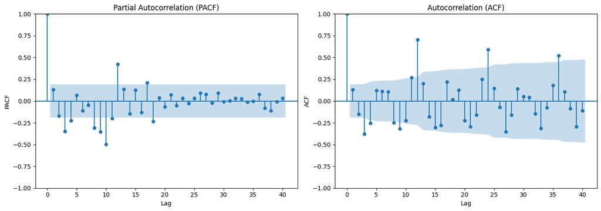

```python
plot_pacf_acf(df_diff_detrended["Sales"], lags=40)
```

### Comment-5

1. It's evident from the PACF and ACF graph that `time series has seasonality of 12 months`

## e. Model fitting

```python
train_size = int(len(df) * 0.8)
train, test = df[0:train_size], df[train_size:]
```

```python
# Fit ARIMA model

model = ARIMA(train, order=(2, 1, 0))
model_fit_1 = model.fit()

# Print model summary
print(model_fit_1.summary())
```

```
                               SARIMAX Results
==============================================================================
Dep. Variable:                  Sales   No. Observations:                   86
Model:                 ARIMA(2, 1, 0)   Log Likelihood                   3.549
Date:                Sun, 03 Aug 2025   AIC                             -1.098
Time:                        17:31:02   BIC                              6.230
Sample:                    01-01-1960   HQIC                             1.850
                         - 02-01-1967
Covariance Type:                  opg
==============================================================================
                 coef    std err          z      P>|z|      [0.025      0.975]
------------------------------------------------------------------------------
ar.L1          0.2060      0.123      1.672      0.094      -0.035       0.448
ar.L2         -0.1929      0.134     -1.443      0.149      -0.455       0.069
sigma2         0.0538      0.009      6.253      0.000       0.037       0.071
===================================================================================
Ljung-Box (L1) (Q):                   0.38   Jarque-Bera (JB):                 4.10
Prob(Q):                              0.54   Prob(JB):                         0.13
Heteroskedasticity (H):               0.89   Skew:                             0.51
Prob(H) (two-sided):                  0.77   Kurtosis:                         3.36
===================================================================================

Warnings:
[1] Covariance matrix calculated using the outer product of gradients (complex-step).
```

```python
model = ARIMA(train, order=(2, 1, 1))
model_fit_2 = model.fit()

# Print model summary
print(model_fit_2.summary())
```

```
                               SARIMAX Results
==============================================================================
Dep. Variable:                  Sales   No. Observations:                   86
Model:                 ARIMA(2, 1, 1)   Log Likelihood                  13.808
Date:                Sun, 03 Aug 2025   AIC                            -19.617
Time:                        17:31:02   BIC                             -9.846
Sample:                    01-01-1960   HQIC                           -15.687
                         - 02-01-1967
Covariance Type:                  opg
==============================================================================
                 coef    std err          z      P>|z|      [0.025      0.975]
------------------------------------------------------------------------------
ar.L1          0.8986      0.090      9.980      0.000       0.722       1.075
ar.L2         -0.4347      0.118     -3.691      0.000      -0.666      -0.204
ma.L1         -0.9114      0.059    -15.361      0.000      -1.028      -0.795
sigma2         0.0416      0.007      5.888      0.000       0.028       0.055
===================================================================================
Ljung-Box (L1) (Q):                   0.92   Jarque-Bera (JB):                 0.36
Prob(Q):                              0.34   Prob(JB):                         0.83
Heteroskedasticity (H):               0.84   Skew:                             0.14
Prob(H) (two-sided):                  0.65   Kurtosis:                         2.86
===================================================================================

Warnings:
[1] Covariance matrix calculated using the outer product of gradients (complex-step).
```

```python
model = ARIMA(train, order=(2, 1, 2))
model_fit_3 = model.fit()

# Print model summary
print(model_fit_3.summary())
```

```
                               SARIMAX Results
==============================================================================
Dep. Variable:                  Sales   No. Observations:                   86
Model:                 ARIMA(2, 1, 2)   Log Likelihood                  18.082
Date:                Sun, 03 Aug 2025   AIC                            -26.164
Time:                        17:31:03   BIC                            -13.951
Sample:                    01-01-1960   HQIC                           -21.252
                         - 02-01-1967
Covariance Type:                  opg
==============================================================================
                 coef    std err          z      P>|z|      [0.025      0.975]
------------------------------------------------------------------------------
ar.L1          1.0004      0.016     62.227      0.000       0.969       1.032
ar.L2         -1.0000      0.000  -2640.670      0.000      -1.001      -0.999
ma.L1         -0.9968      0.048    -20.761      0.000      -1.091      -0.903
ma.L2          1.0000      0.024     41.776      0.000       0.953       1.047
sigma2         0.0354      0.005      7.158      0.000       0.026       0.045
===================================================================================
Ljung-Box (L1) (Q):                   0.14   Jarque-Bera (JB):                 1.96
Prob(Q):                              0.71   Prob(JB):                         0.38
Heteroskedasticity (H):               0.80   Skew:                            -0.16
Prob(H) (two-sided):                  0.57   Kurtosis:                         3.67
===================================================================================

Warnings:
[1] Covariance matrix calculated using the outer product of gradients (complex-step).
[2] Covariance matrix is singular or near-singular, with condition number 6.49e+16. Standard errors may be unstable.
```

```python
model = ARIMA(train, order=((1, 1, 0, 0), 1, (1, 1, 0, 0)))
model_fit_4 = model.fit()

# Print model summary
print(model_fit_4.summary())
```

```
                               SARIMAX Results
==============================================================================
Dep. Variable:                  Sales   No. Observations:                   86
Model:                 ARIMA(2, 1, 2)   Log Likelihood                  18.082
Date:                Sun, 03 Aug 2025   AIC                            -26.164
Time:                        17:31:03   BIC                            -13.951
Sample:                    01-01-1960   HQIC                           -21.252
                         - 02-01-1967
Covariance Type:                  opg
==============================================================================
                 coef    std err          z      P>|z|      [0.025      0.975]
------------------------------------------------------------------------------
ar.L1          1.0004      0.016     62.227      0.000       0.969       1.032
ar.L2         -1.0000      0.000  -2640.670      0.000      -1.001      -0.999
ma.L1         -0.9968      0.048    -20.761      0.000      -1.091      -0.903
ma.L2          1.0000      0.024     41.776      0.000       0.953       1.047
sigma2         0.0354      0.005      7.158      0.000       0.026       0.045
===================================================================================
Ljung-Box (L1) (Q):                   0.14   Jarque-Bera (JB):                 1.96
Prob(Q):                              0.71   Prob(JB):                         0.38
Heteroskedasticity (H):               0.80   Skew:                            -0.16
Prob(H) (two-sided):                  0.57   Kurtosis:                         3.67
===================================================================================

Warnings:
[1] Covariance matrix calculated using the outer product of gradients (complex-step).
[2] Covariance matrix is singular or near-singular, with condition number 6.49e+16. Standard errors may be unstable.
```

```python
model = ARIMA(train, order=((0, 0, 1, 1), 1, (0, 0, 1, 1)))
model_fit_5 = model.fit()

# Print model summary
print(model_fit_5.summary())
```

```
                                  SARIMAX Results
====================================================================================
Dep. Variable:                        Sales   No. Observations:                   86
Model:             ARIMA([3, 4], 1, [3, 4])   Log Likelihood                  13.607
Date:                      Sun, 03 Aug 2025   AIC                            -17.214
Time:                              17:31:03   BIC                             -5.001
Sample:                          01-01-1960   HQIC                           -12.302
                               - 02-01-1967
Covariance Type:                        opg
==============================================================================
                 coef    std err          z      P>|z|      [0.025      0.975]
------------------------------------------------------------------------------
ar.L3         -0.0091      0.225     -0.040      0.968      -0.450       0.432
ar.L4         -0.0742      0.207     -0.358      0.720      -0.480       0.331
ma.L3         -0.5087      0.208     -2.451      0.014      -0.915      -0.102
ma.L4         -0.2721      0.177     -1.539      0.124      -0.619       0.074
sigma2         0.0417      0.007      5.691      0.000       0.027       0.056
===================================================================================
Ljung-Box (L1) (Q):                   0.20   Jarque-Bera (JB):                 0.08
Prob(Q):                              0.65   Prob(JB):                         0.96
Heteroskedasticity (H):               0.85   Skew:                            -0.03
Prob(H) (two-sided):                  0.66   Kurtosis:                         2.86
===================================================================================

Warnings:
[1] Covariance matrix calculated using the outer product of gradients (complex-step).
```

```python
model = SARIMAX(train, order=(2, 1, 0), seasonal_order=(2, 1, 0, 12))
model_fit_s1 = model.fit()

# Print model summary
print(model_fit_s1.summary())
```

```
                                     SARIMAX Results
==========================================================================================
Dep. Variable:                              Sales   No. Observations:                   86
Model:             SARIMAX(2, 1, 0)x(2, 1, 0, 12)   Log Likelihood                  46.436
Date:                            Sun, 03 Aug 2025   AIC                            -82.872
Time:                                    17:31:03   BIC                            -71.420
Sample:                                01-01-1960   HQIC                           -78.308
                                     - 02-01-1967
Covariance Type:                              opg
==============================================================================
                 coef    std err          z      P>|z|      [0.025      0.975]
------------------------------------------------------------------------------
ar.L1         -0.5521      0.112     -4.939      0.000      -0.771      -0.333
ar.L2         -0.0687      0.141     -0.487      0.626      -0.345       0.208
ar.S.L12      -0.3492      0.124     -2.824      0.005      -0.591      -0.107
ar.S.L24      -0.2432      0.159     -1.532      0.126      -0.554       0.068
sigma2         0.0158      0.002      6.473      0.000       0.011       0.021
===================================================================================
Ljung-Box (L1) (Q):                   0.04   Jarque-Bera (JB):                 1.76
Prob(Q):                              0.84   Prob(JB):                         0.41
Heteroskedasticity (H):               0.90   Skew:                            -0.21
Prob(H) (two-sided):                  0.79   Kurtosis:                         3.64
===================================================================================

Warnings:
[1] Covariance matrix calculated using the outer product of gradients (complex-step).
```

```python
model = SARIMAX(train, order=(2, 1, 1), seasonal_order=(2, 1, 1, 12))
model_fit_s2 = model.fit()

# Print model summary
print(model_fit_s2.summary())
```

```
                                     SARIMAX Results
==========================================================================================
Dep. Variable:                              Sales   No. Observations:                   86
Model:             SARIMAX(2, 1, 1)x(2, 1, 1, 12)   Log Likelihood                  51.124
Date:                            Sun, 03 Aug 2025   AIC                            -88.248
Time:                                    17:31:04   BIC                            -72.215
Sample:                                01-01-1960   HQIC                           -81.859
                                     - 02-01-1967
Covariance Type:                              opg
==============================================================================
                 coef    std err          z      P>|z|      [0.025      0.975]
------------------------------------------------------------------------------
ar.L1          0.2581      0.168      1.536      0.124      -0.071       0.587
ar.L2          0.2212      0.158      1.397      0.162      -0.089       0.531
ma.L1         -0.9641      0.150     -6.447      0.000      -1.257      -0.671
ar.S.L12      -1.1283      0.718     -1.572      0.116      -2.535       0.278
ar.S.L24      -0.4088      0.201     -2.031      0.042      -0.803      -0.014
ma.S.L12       0.8289      1.015      0.817      0.414      -1.160       2.817
sigma2         0.0131      0.004      3.636      0.000       0.006       0.020
===================================================================================
Ljung-Box (L1) (Q):                   0.00   Jarque-Bera (JB):                 6.27
Prob(Q):                              1.00   Prob(JB):                         0.04
Heteroskedasticity (H):               0.77   Skew:                            -0.15
Prob(H) (two-sided):                  0.53   Kurtosis:                         4.40
===================================================================================

Warnings:
[1] Covariance matrix calculated using the outer product of gradients (complex-step).
```

```python
model = SARIMAX(train, order=(2, 1, 2), seasonal_order=(2, 1, 2, 12))
model_fit_s3 = model.fit()

# Print model summary
print(model_fit_s3.summary())
```

```
                                     SARIMAX Results
==========================================================================================
Dep. Variable:                              Sales   No. Observations:                   86
Model:             SARIMAX(2, 1, 2)x(2, 1, 2, 12)   Log Likelihood                  52.771
Date:                            Sun, 03 Aug 2025   AIC                            -87.542
Time:                                    17:31:04   BIC                            -66.928
Sample:                                01-01-1960   HQIC                           -79.327
                                     - 02-01-1967
Covariance Type:                              opg
==============================================================================
                 coef    std err          z      P>|z|      [0.025      0.975]
------------------------------------------------------------------------------
ar.L1         -0.2108      0.422     -0.500      0.617      -1.037       0.615
ar.L2          0.3939      0.169      2.332      0.020       0.063       0.725
ma.L1         -0.5077      0.512     -0.991      0.321      -1.511       0.496
ma.L2         -0.4527      0.397     -1.140      0.254      -1.231       0.325
ar.S.L12      -0.4802      2.499     -0.192      0.848      -5.377       4.417
ar.S.L24       0.3547      1.390      0.255      0.799      -2.371       3.080
ma.S.L12      -0.0769     28.311     -0.003      0.998     -55.566      55.412
ma.S.L24      -0.9182     27.891     -0.033      0.974     -55.583      53.746
sigma2         0.0107      0.310      0.035      0.972      -0.596       0.618
===================================================================================
Ljung-Box (L1) (Q):                   0.02   Jarque-Bera (JB):                 5.89
Prob(Q):                              0.89   Prob(JB):                         0.05
Heteroskedasticity (H):               0.99   Skew:                            -0.34
Prob(H) (two-sided):                  0.97   Kurtosis:                         4.21
===================================================================================

Warnings:
[1] Covariance matrix calculated using the outer product of gradients (complex-step).
```

```python
model = SARIMAX(train, order=(1, 1, 1), seasonal_order=(1, 0, 0, 12))
model_fit_s6 = model.fit()

# Print model summary
print(model_fit_s6.summary())
```

```
                                      SARIMAX Results
===========================================================================================
Dep. Variable:                               Sales   No. Observations:                   86
Model:             SARIMAX(1, 1, 1)x(1, 0, [], 12)   Log Likelihood                  46.415
Date:                             Sun, 03 Aug 2025   AIC                            -84.830
Time:                                     17:31:04   BIC                            -75.059
Sample:                                 01-01-1960   HQIC                           -80.900
                                      - 02-01-1967
Covariance Type:                               opg
==============================================================================
                 coef    std err          z      P>|z|      [0.025      0.975]
------------------------------------------------------------------------------
ar.L1          0.3019      0.112      2.696      0.007       0.082       0.521
ma.L1         -0.9339      0.040    -23.112      0.000      -1.013      -0.855
ar.S.L12       0.8385      0.056     15.039      0.000       0.729       0.948
sigma2         0.0164      0.002      7.109      0.000       0.012       0.021
===================================================================================
Ljung-Box (L1) (Q):                   0.54   Jarque-Bera (JB):                 4.85
Prob(Q):                              0.46   Prob(JB):                         0.09
Heteroskedasticity (H):               0.78   Skew:                            -0.29
Prob(H) (two-sided):                  0.51   Kurtosis:                         4.02
===================================================================================

Warnings:
[1] Covariance matrix calculated using the outer product of gradients (complex-step).
```

```python
model = SARIMAX(train, order=(2, 1, 1), seasonal_order=(2, 0, 1, 12))
model_fit_s4 = model.fit()

# Print model summary
print(model_fit_s4.summary())
```

```
                                     SARIMAX Results
==========================================================================================
Dep. Variable:                              Sales   No. Observations:                   86
Model:             SARIMAX(2, 1, 1)x(2, 0, 1, 12)   Log Likelihood                  52.460
Date:                            Sun, 03 Aug 2025   AIC                            -90.919
Time:                                    17:31:05   BIC                            -73.821
Sample:                                01-01-1960   HQIC                           -84.042
                                     - 02-01-1967
Covariance Type:                              opg
==============================================================================
                 coef    std err          z      P>|z|      [0.025      0.975]
------------------------------------------------------------------------------
ar.L1          0.2899      0.120      2.406      0.016       0.054       0.526
ar.L2          0.2142      0.149      1.435      0.151      -0.078       0.507
ma.L1         -0.9514      0.046    -20.782      0.000      -1.041      -0.862
ar.S.L12       1.2893      0.386      3.343      0.001       0.533       2.045
ar.S.L24      -0.2994      0.356     -0.840      0.401      -0.998       0.399
ma.S.L12      -0.7607      0.456     -1.667      0.095      -1.655       0.133
sigma2         0.0129      0.003      4.530      0.000       0.007       0.018
===================================================================================
Ljung-Box (L1) (Q):                   0.05   Jarque-Bera (JB):                 6.38
Prob(Q):                              0.83   Prob(JB):                         0.04
Heteroskedasticity (H):               1.03   Skew:                            -0.33
Prob(H) (two-sided):                  0.94   Kurtosis:                         4.17
===================================================================================

Warnings:
[1] Covariance matrix calculated using the outer product of gradients (complex-step).
```

```python
model = SARIMAX(train, order=(2, 1, 2), seasonal_order=(2, 0, 2, 12))
model_fit_s5 = model.fit()

# Print model summary
print(model_fit_s5.summary())
```

```
                                     SARIMAX Results
==========================================================================================
Dep. Variable:                              Sales   No. Observations:                   86
Model:             SARIMAX(2, 1, 2)x(2, 0, 2, 12)   Log Likelihood                  45.978
Date:                            Sun, 03 Aug 2025   AIC                            -73.955
Time:                                    17:31:06   BIC                            -51.972
Sample:                                01-01-1960   HQIC                           -65.113
                                     - 02-01-1967
Covariance Type:                              opg
==============================================================================
                 coef    std err          z      P>|z|      [0.025      0.975]
------------------------------------------------------------------------------
ar.L1          1.0115      0.105      9.662      0.000       0.806       1.217
ar.L2         -0.8432      0.121     -6.988      0.000      -1.080      -0.607
ma.L1         -1.2207      0.090    -13.575      0.000      -1.397      -1.044
ma.L2          0.9627      0.107      8.989      0.000       0.753       1.173
ar.S.L12       0.2551      0.261      0.977      0.329      -0.257       0.767
ar.S.L24       0.7413      0.259      2.867      0.004       0.234       1.248
ma.S.L12       0.0637      1.074      0.059      0.953      -2.041       2.169
ma.S.L24      -0.8903      1.277     -0.697      0.486      -3.393       1.612
sigma2         0.0131      0.015      0.872      0.383      -0.016       0.043
===================================================================================
Ljung-Box (L1) (Q):                   3.57   Jarque-Bera (JB):                 2.45
Prob(Q):                              0.06   Prob(JB):                         0.29
Heteroskedasticity (H):               0.97   Skew:                            -0.21
Prob(H) (two-sided):                  0.93   Kurtosis:                         3.72
===================================================================================

Warnings:
[1] Covariance matrix calculated using the outer product of gradients (complex-step).
```

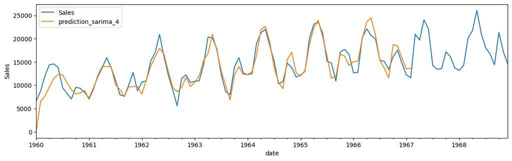

```python
# Predict present data
# data is in log scale, so we need to convert it back to original scale
df["Sales"] = np.exp(df["Sales"])  # Convert back to original scale
df["prediction_arima_2"] = np.exp(model_fit_2.predict())
df["prediction_arima_3"] = np.exp(model_fit_3.predict())
df["prediction_sarima_2"] = np.exp(model_fit_s2.predict())
df["prediction_sarima_4"] = np.exp(model_fit_s4.predict())
df[
    [
        "Sales",
        # "prediction_arima_2",
        # "prediction_arima_3",
        # "prediction_sarima_2",
        "prediction_sarima_4",
    ]
].plot(figsize=(14, 4))
plt.ylabel("Sales")
plt.show()
```

### Comment-6

| # | p | d | q | P | D | Q | s | AIC | BIC |
| --- | --- | --- | --- | --- | --- | --- | --- | --- | --- |
| 1 | 2 | 1 | 1 | 2 | 1 | 1 | 12 | -88.248 | -72.215 |
| 2 | 2 | 1 | 2 | 2 | 1 | 2 | 12 | -87.542 | -66.928 |
| 3 | 2 | 1 | 1 | 2 | 0 | 1 | 12 | -90.919 | -73.821 |
| 4 | 2 | 1 | 2 | 2 | 0 | 2 | 12 | -73.955 | -51.972 |

Note: Residual in all above scenario are independent or white noise.